# A {fun} Intro to R Programming

Pre-Workshop To-Do List

[figure not shown]

Welcome to the **pre-workshop to-do list** for the [`Intro to R Programming workshop`](https://ds3.ai/2023/rprogramming.htmll) during the [*Data Science Summer School (DS3) 2023*](https://ds3.ai/)!

This workshop is taught using `R` and `RStudio` on your computer. So some minor preparations are necessary for a smooth experience. They should not take too long for you to complete and hopefully we can avoid any surprises on the day of the workshop!

## Install

First of all, we want to download R. Find below install links depending on your operating system:

- [Download R for Linux](https://cran.r-project.org/bin/linux/) ([Debian](https://cran.r-project.org/bin/linux/debian), [Fedora/Redhat](https://cran.r-project.org/bin/linux/fedora), [Ubuntu)](https://cran.r-project.org/bin/linux/ubuntu)
- [Download R for macOS](https://cran.r-project.org/bin/macosx/)
- [Download R for Windows](https://cran.r-project.org/bin/windows/)

## Install

Next, please download & install RStudio.

RStudio is a graphical interface in which we can program in R. You can write, save and open R Code within RStudio an it also provides syntax-highlighting, auto-completion & many more conveniences!

### **VERY IMPORTANT:**

**Please make sure you have the *latest version* of RStudio installed.**

It should be at least any version more recent than July 2022 (`2022.07.0+548`) which can be [**downloaded here**](https://www.rstudio.com/products/rstudio/download/#download). We are going to use some brand new features in RStudio during this workshop, so please make sure you have an updated version!

## 💻 Download Workshop files

Please download the workshop files from this [**Dropbox folder**](https://www.dropbox.com/sh/jievqgwl43nwnbf/AADhoYQW5oMZ-JygK7aNklHra?dl=0).

The link will download a `.zip` file. Extract it to **its own folder**:

[figure not shown]

The contents of the new folder should look like this:

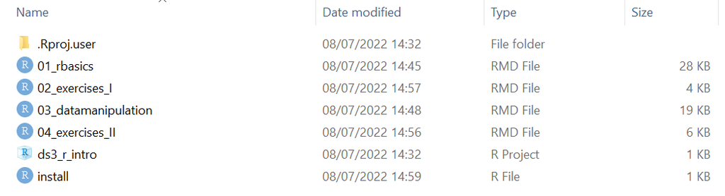

On to the final step!

## 📦 Install R packages

Finally, we need some R packages. It will be convenient if you already have the necessary R packages installed for the workshop.

*Packages are at the heart of R:*

- R packages are basically a collection of additional R functionalities that you can use.
- They contain code that other R users have prepared for the community.

### Instructions

1. *Double-click* on the `install.R` file

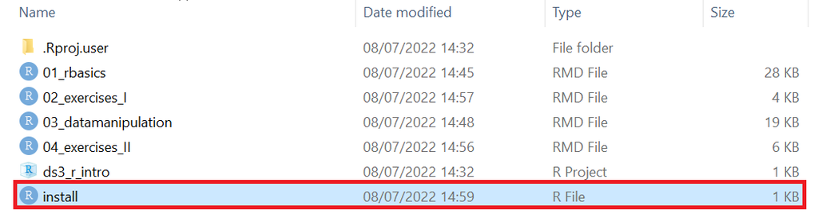

This will open your RStudio environment with the `install.R` script open.

2. Next, click on the `Source` tab which will run all the R code in your script (as opposed to `Run`, which will only run the R code you select!).

[figure not shown]

3. You should see some code running in your console like this:

[figure not shown]

Let it run and it should be done after a few moments.

*Note:* If you use Ubuntu Linux then you need to install the following non-R packages on your computer before you can install the `tidyverse`:

```bash
sudo apt install libcurl4-openssl-dev libssl-dev libxml2-dev
```

## 🎉 All Set 🎉

**Congratulations!**

Now you have everything installed on your computer and the fun can begin! 🎉🎉🎉